# HAR Data Analysis

Bernhard Suhm

Thursday, May 23, 2015

## Preparation

(Note to myself for future reference) This work will access the caret package, kernlab (for the spam dataset), and Hmisc. Remember you need two steps, install.packages, followed by library.

We begin by loading the training data set and partitioning it into 60% training and 40% for and cross validation and testing.

```r
nzv_har <- nearZeroVar(train_har,saveMetrics=TRUE)
sum(nzv_har$nzv==TRUE)
```

```
## [1] 30
```

```r
train<-train_har[!nzv_har$nzv]
heldout<-heldout_har[!nzv_har$nzv]
testSplit <- createDataPartition(heldout$classe,p=0.5,list=FALSE)
test<-heldout[testSplit,]
crossVal<-heldout[-testSplit,]
```

Then I explored which variables separated the outcome variables visually in plots, and this only among the non near zero ones. Visually, the following variables had some predictive power: * All three belt (roll, pitch, yaw), max_roll_belt, max_pitch_belt * forearm: pitch and roll though then I realized that all but the 52 “original” data variables were primarily NA values, hence not suitable for model training. With “original” I mean the ones that represent sensor measurements, as opposed to those derived from measurements by applying a window over the original data - thanks to Edward Drake for explaining this so nicely in the discussion forum! I suspect something is wrong with the data offered on the website, i.e., there was a bug when they calculated those derived measures. So for the model training phase, we’ll just be using the 52 variables.

[figure not shown]

```r
PCA<-preProcess(train[,6:58],method="pca",pcaComp=2)
qplot(PC1,PC2,data=predict(PCA,train[,6:58]),color=train$user_name)
```

## Model Training

First, I wanted to train a linear model, even though my intuition suggested that’s probably not a good fit for this problem. The caret train function had trouble using all variables, but then I used the gbm package and succeeded training a model.

```r
library(gbm)
fol52 <- formula(classe ~ roll_forearm + pitch_forearm + yaw_forearm + total_accel_forearm + gyros_forearm_x +gyros_forearm_y +  gyros_forearm_z + accel_forearm_x + accel_forearm_y + accel_forearm_z + magnet_forearm_x + magnet_forearm_y + magnet_forearm_z + roll_belt + pitch_belt + yaw_belt + total_accel_belt + gyros_belt_x +gyros_belt_y +  gyros_belt_z + accel_belt_x + accel_belt_y + accel_belt_z + magnet_belt_x + magnet_belt_y + magnet_belt_z + roll_dumbbell + pitch_dumbbell + yaw_dumbbell + total_accel_dumbbell + gyros_dumbbell_x +gyros_dumbbell_y +  gyros_dumbbell_z + accel_dumbbell_x + accel_dumbbell_y + accel_dumbbell_z + magnet_dumbbell_x + magnet_dumbbell_y + magnet_dumbbell_z+roll_arm + pitch_arm + yaw_arm + total_accel_arm + gyros_arm_x +gyros_arm_y +  gyros_arm_z + accel_arm_x + accel_arm_y + accel_arm_z + magnet_arm_x + magnet_arm_y + magnet_arm_z)
m_gbm <- gbm(fol52,data=train)
```

```
## Distribution not specified, assuming multinomial ...
```

```r
p_gbm<- predict(m_gbm,crossVal,n.trees=100,type="response")
pCV_gbm<-apply(p_gbm,1,which.max) # need to pick out best choice since predict returns a vector of pseudo probs
accCV_gbm<-sum(pCV_gbm==as.numeric(crossVal$classe))/nrow(crossVal)
```

The dominant variables in this model by far are roll_belt and pitch_forearm, with some influence by magnet_dumbbell_y, accel_forearm_x, and roll_dumbbell. Only two other variables have non zero influence at all: gyros_dumbbell_y and accel_dumbbel_x. The fact that only 7 out of 52 predictors had a non-zero influence is somewhat disconcerning. Therefore not surprisingly, it’s accuracy is rather low, 50% on the cross validation set. We are even less surprised when we plot the two dominant variables against the classes, we see some nice separation - but clearly not with hyperplanes (linear functions).

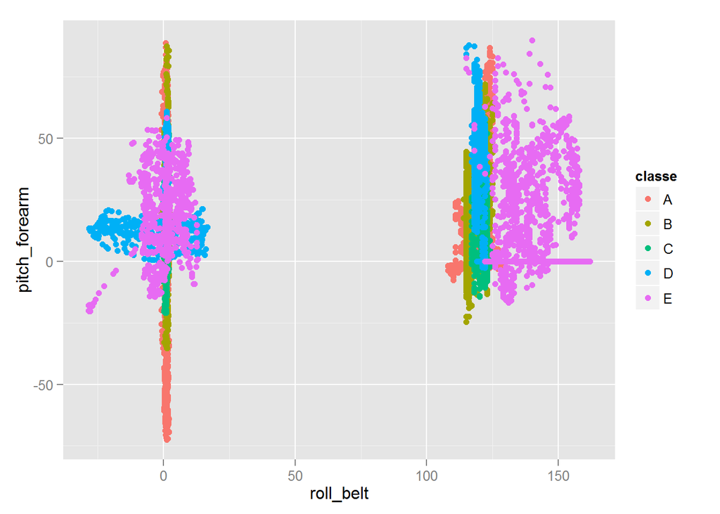

```r
qplot(roll_belt,pitch_forearm,color=classe,data=train)
```

Next I tried LDA, more for practice than seriously expecting it to be the best performer, since I already mentioned earlier the plots aren’t separable by hyperplanes upon visual inspection of some clearly important predictor variables.

```r
m_lda<-train(fol52,method="lda",data=train)
p_lda <- predict(m_lda,crossVal,type="raw")
acc_lda <- sum(p_lda==crossVal$classe)/nrow(crossVal)
```

This model gets 69.9% accuracy on cross validation. Reducing the variables with PCA (using the preprocessing step that’s built into the caret train package) actually lowers the accuracy to 53.3%.

Next, I trained a random forest on those same 52 variables, using the randomForest package that Bill Howe from University of Washington uses in his Data Science class. It runs a lot faster than the corresponding variant of train in the caret package!

```r
library(randomForest)
m_rf <- randomForest(fol52,data=train)
p_rf <- predict(m_rf,crossVal,type="class")
acc_rf <- sum(p_rf==crossVal$classe)/nrow(crossVal)
```

That model got a surprising 99.3% accuracy on the cross validation set. Let’s see which variables had the greatest influence - roll_best, yaw_belt, pitch_forearm, and plot the top two against the categories like above:

```r
rf_imp <- importance(m_rf)
sort(rf_imp[,1],decreasing=TRUE)
```

```
##            roll_belt             yaw_belt        pitch_forearm
##            759.31656            549.62357            447.73586
##    magnet_dumbbell_z    magnet_dumbbell_y           pitch_belt
##            445.75362            416.39375            401.94882
##         roll_forearm    magnet_dumbbell_x     accel_dumbbell_y
##            379.35427            291.84005            253.94188
##        roll_dumbbell        magnet_belt_z         accel_belt_z
##            243.42660            240.83161            239.19039
##        magnet_belt_y     accel_dumbbell_z      accel_forearm_x
##            228.80377            198.10020            192.51842
##         gyros_belt_z             roll_arm     magnet_forearm_z
##            192.06933            178.95241            167.72030
## total_accel_dumbbell     accel_dumbbell_x        magnet_belt_x
##            162.43095            161.47352            151.57775
##          accel_arm_x         magnet_arm_x         yaw_dumbbell
##            149.69931            149.31205            149.12177
##              yaw_arm     gyros_dumbbell_y     magnet_forearm_x
##            148.99475            146.61815            139.64138
##      accel_forearm_z     total_accel_belt     magnet_forearm_y
##            139.41386            137.07541            133.02356
##         magnet_arm_y       pitch_dumbbell         magnet_arm_z
##            129.68178            110.07066            109.66189
##          yaw_forearm            pitch_arm          accel_arm_y
##            108.27692             97.93674             89.29509
##      accel_forearm_y          gyros_arm_x          gyros_arm_y
##             82.64631             81.48942             79.20012
##          accel_arm_z         accel_belt_y      gyros_forearm_y
##             78.95121             78.78026             78.09649
##     gyros_dumbbell_x         accel_belt_x         gyros_belt_y
##             73.50621             72.05887             68.75060
##  total_accel_forearm         gyros_belt_x      total_accel_arm
##             66.20136             60.98127             60.32036
##      gyros_forearm_z      gyros_forearm_x     gyros_dumbbell_z
##             54.60358             48.93728             46.46618
##          gyros_arm_z
##             37.80878
```

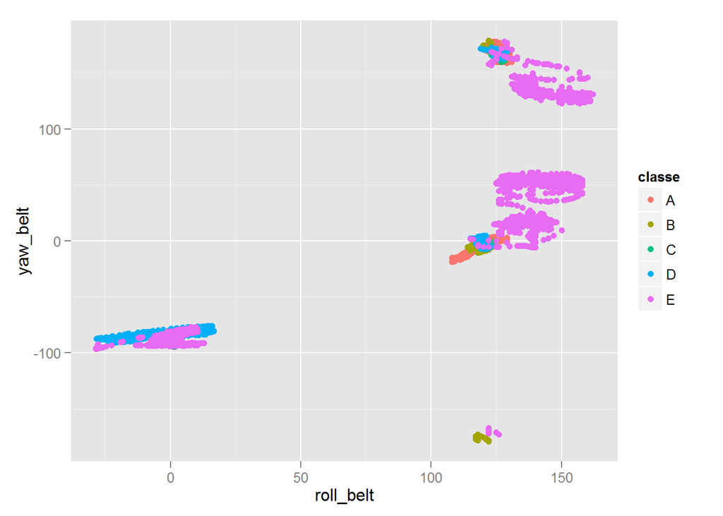

```r
qplot(roll_belt,yaw_belt,color=classe,data=train)
```

This high an accuracy was surprising to me (and many co-students on the discussion forums), but the HAR paper and website mentions an accuracy of >99%.

## Model Evaluation

The accuracy of that random forest on the held-out test set is 99.4%. So this should be a good predictor of the accuracy of this model on new (unseen) data. Now it’s time to evaluate the model on the 20 test cases. Turns out to be 20 out of 20 cases.